# Calculate Accuracy of Merged CDL/NVC Raster

Melanie Kammerer

2/15/2022

## Objective

The goal of this script is to map the accuracy of CDL & NVC combined rasters. To do this, I use class-level data on spatial accuracy from USDA NASS and LANDFIRE for CDL and NVC, respectively. I combined accuracy statistics from two layers by calculating an area-weighted mean.

I start by loading accuracy data for EVT and NVC. We need NVC and EVT because NVC borrows some classes from EVT and LANDFIRE does not publish accuracy values for EVT classes in NVC data files. In this section I also create a list of LANDFIRE ‘managed classes’ (agriculture, burned, logged, etc). These classes were not included in reference database nor accuracy assessment so, when calculating data coverage, I exclude area covered in these classes.

```
## terra version 1.4.22
```

## Load NVC pixel frequency by county

Here, I load datasets generated by ‘TabulatePixels3Rasters.R’ script. All LANDFIRE accuracy assessments were conducted by region, so I also need to load a shapefile of the LF regions and label each county with the region it is contained within. Some counties cross regional boundaries, so I determine the appropriate region based on the centroid of each county polygons (some counties have multiple polygons due to non-contiguous land).

```
## character(0)
```

## Join NVC accuracy metrics with pixel frequency

```r
# join accuracy values to pixel frequency data
nvc_accuracy <- dplyr::left_join(merged_freq, dplyr::select(nvc_classes, VALUE, NVC_Name), by=c('Class'= 'VALUE')) %>%
  dplyr::distinct() %>%
  dplyr::left_join(dplyr::select(lf, -LANDFIRE_NVC, -LANDFIRE_Name, -LANDFIRE_EVT),
                   by=c('Class'='LANDFIRE_Class', 'LF2010_Region'='Region')) %>%
  dplyr::select(-contains('.evt') , -contains('.nvc'))

# why are there some counties with NA for NVC value?
nvc_accuracy[is.na(nvc_accuracy$Class),]
```

```
##  [1] STATE                  COUNTY                 LF2010_Region
##  [4] Class                  NCells                 PctCounty
##  [7] NVC_Name               ProducerAccuracy       ProducerNPlots_autokey
## [10] UserAccuracy           UserNPlots_map
## <0 rows> (or 0-length row.names)
```

```r
# make new variable of reference database status (well-represented, poorly-represented, absent, or managed/ag)
nvc_accuracy$RFDB_Status <- if_else(nvc_accuracy$Class %in% managed_classes, 'absent, managed/ag/disturbed',
                            if_else((nvc_accuracy$ProducerNPlots_autokey == 0|is.na(nvc_accuracy$ProducerNPlots_autokey)) &
                                 !nvc_accuracy$Class %in% managed_classes,  'absent, could be added',
                            if_else(nvc_accuracy$ProducerNPlots_autokey >= 30, 'well-represented',
                            if_else(nvc_accuracy$ProducerNPlots_autokey < 30 & nvc_accuracy$ProducerNPlots_autokey > 0, 'poorly-represented',
                                  'not NVC'))))
```

## Join CDL accuracy metrics with pixel frequency

```r
cdl <- read.csv('./data/CDL_Accuracy/CDL_accuracy_long_allstates_2012to2020.csv')  %>%
  dplyr::mutate(GT_Status = if_else(is.na(Producer), "no ground-truth", "present")) %>%
  dplyr::rename(ProducerAccuracy=Producer, UserAccuracy=User) %>%
  dplyr::mutate(CDL_Class = -CDL_Class)

# filter cdl to 2016 to match pixel freq data
cdl_oneyear <- dplyr::filter(cdl, Year %in% CDLYear)

#cdl_freq <- read.csv(paste0('./data/PixelFreq/CDL', CDLYear, '_CountyPixelFreq.csv'))

head(cdl_oneyear)
```

```
##   Year State  CDL_Name CDL_Class UserAccuracy Commission Kappa_User
## 1 2016    AL      Corn        -1    0.9373833 0.06261666  0.9310374
## 2 2016    AL    Cotton        -2    0.8663614 0.13363862  0.8520341
## 3 2016    AL      Rice        -3           NA         NA         NA
## 4 2016    AL   Sorghum        -4    0.6774436 0.32255639  0.6767527
## 5 2016    AL  Soybeans        -5    0.8525808 0.14741924  0.8381123
## 6 2016    AL Sunflower        -6    0.0000000 1.00000000  0.0000000
##   ProducerAccuracy   Omission Kappa_Producer       GT_Status
## 1        0.9414107 0.05858929      0.9354448         present
## 2        0.8897139 0.11028614      0.8775363         present
## 3               NA         NA             NA no ground-truth
## 4        0.4516291 0.54837093      0.4508465         present
## 5        0.8615853 0.13841469      0.8478429         present
## 6               NA         NA             NA no ground-truth
```

```r
combined_accuracy <- dplyr::left_join(nvc_accuracy, cdl_oneyear,  by=c('Class'='CDL_Class',
                                                                  'STATE'='State'), suffix=c('.nvc', '.cdl'))
```

## Calculate area-weighted version of accuracy

```r
# calculate total number of cells per county as well as accuracy*NCells of a specific class (will sum in next step to get area-weighted average)
combined_accuracy2 <- dplyr::group_by(combined_accuracy, STATE, COUNTY, Class) %>%
  dplyr::mutate(ProducerAccuracy=mymax(ProducerAccuracy.nvc, ProducerAccuracy.cdl, na.rm=T),
                                   UserAccuracy=mymax(UserAccuracy.nvc, UserAccuracy.cdl, na.rm=T), # select source of accuracy value
                                   ClassStatusLong= if_else(is.na(CDL_Name), paste0('nvc: ', RFDB_Status), paste0('cdl: ',GT_Status)),
                ClassStatusShort = if_else(ClassStatusLong %in% c('cdl: present', 'nvc: well-represented'), 'well-represented',
                                   if_else(ClassStatusLong %in% c('nvc: poorly-represented'), 'poorly-represented', 'absent')),
                DataSource= if_else(grepl(ClassStatusLong, pattern='nvc: '), 'NVC',
                                   if_else(grepl(ClassStatusLong, pattern='cdl: '), 'CDL', 'uh-oh'))) %>%
  dplyr::ungroup() %>%
  dplyr::group_by(STATE, COUNTY) %>%
  dplyr::mutate(NCells_County= sum(NCells),
                Weight_ProdAcc = NCells*ProducerAccuracy,
                Weight_UserAcc = NCells*UserAccuracy,
                NCells_CDL = sum(NCells[DataSource == 'CDL']),
                NCells_NVC = sum(NCells[DataSource == 'NVC'])) %>%
  dplyr::group_by(STATE, COUNTY, NCells_CDL, NCells_NVC, NCells_County, ClassStatusShort)

table(combined_accuracy2$ClassStatusShort)
```

```
##
##             absent poorly-represented   well-represented
##             115713              17302              92008
```

```r
# summarize ncell and accuracy by county and reference db status
# accuracy only applies to well-represented, but we will map data coverage of well and poorly represented classes
combined_accuracy_bycounty <-  combined_accuracy2  %>% dplyr::summarize(NCells_Group = sum(NCells, na.rm=T),
    Weight_ProdAcc = sum(Weight_ProdAcc, na.rm=T)/NCells_Group,
    Weight_UserAcc = sum(Weight_UserAcc, na.rm=T)/NCells_Group, .groups='keep') %>%
  dplyr::mutate(ClassStatusShort2=ClassStatusShort) %>%
  dplyr::ungroup()

# reshape ncells to wide format
ncells <- tidyr::pivot_wider(combined_accuracy_bycounty, id_cols=c(STATE:COUNTY, NCells_CDL, NCells_NVC, NCells_County),   names_from=ClassStatusShort, values_from=NCells_Group) %>%
  tidyr::replace_na(list(`well-represented` = 0, `poorly-represented` = 0))

# reshape accuracy to wide format, filter to only well-represented classes
acc <- dplyr::filter(combined_accuracy_bycounty, ClassStatusShort == 'well-represented') %>%
  tidyr::pivot_wider(id_cols=c(STATE:COUNTY, NCells_CDL, NCells_NVC, NCells_County), names_from=ClassStatusShort,
                     values_from=c(Weight_ProdAcc, Weight_UserAcc)) %>%
  dplyr::rename(WtdUserAcc = `Weight_UserAcc_well-represented`, WtdProdAcc = `Weight_ProdAcc_well-represented`)

# translate ncells to percentage of un-managed area in each county
toplot <- dplyr::mutate(ncells, PropCDL = NCells_CDL/NCells_County,
                        Rep_PctCounty = (`well-represented` + `poorly-represented`)/NCells_County,
                        WellRep_PctCounty = (`well-represented`)/NCells_County)
```

## Make maps of NVC data coverage and accuracy

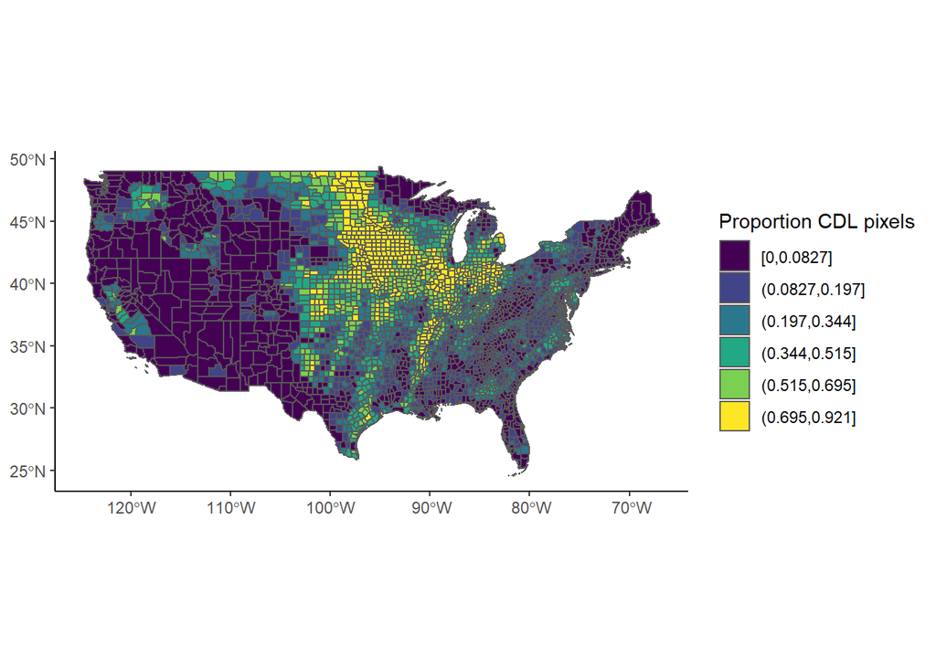

```r
library(classInt); library(ggplot2); library(viridis)
# join results to spatial object for mapping
toplot_sf <- dplyr::left_join(county, toplot) %>%
  dplyr::left_join(acc)
PropCDL.jenks = BAMMtools::getJenksBreaks(toplot_sf$PropCDL, k = 7)
toplot_sf$PropCDL.jenks = cut(toplot_sf$PropCDL, breaks=PropCDL.jenks, include.lowest = TRUE)

# map proportion of each country from CDL
propcdl_map  <- ggplot() + geom_sf(data=toplot_sf, aes(fill=PropCDL.jenks)) +
  guides(fill=guide_legend(title='Proportion CDL pixels')) +
  theme_classic() +
  scale_fill_viridis(discrete=T)
propcdl_map
```

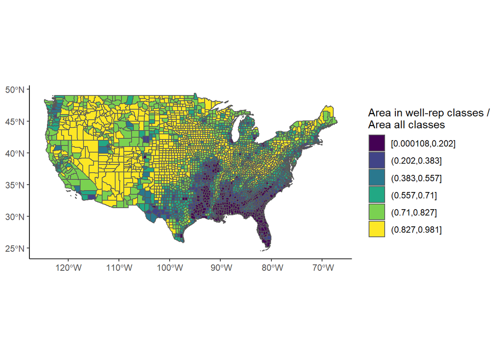

```r
# maps of data coverage
natural.interval = BAMMtools::getJenksBreaks(toplot_sf$WellRep_PctCounty, k = 7)
toplot_sf$population.natural.well = cut(toplot_sf$WellRep_PctCounty, breaks=natural.interval, include.lowest = TRUE)

wellrep_map_jenks <- ggplot() + geom_sf(data=toplot_sf, aes(fill=population.natural.well)) +
  guides(fill=guide_legend(title='Area in well-rep classes /\nArea all classes')) +
  theme_classic() +
  scale_fill_viridis(discrete=T)
wellrep_map_jenks
```

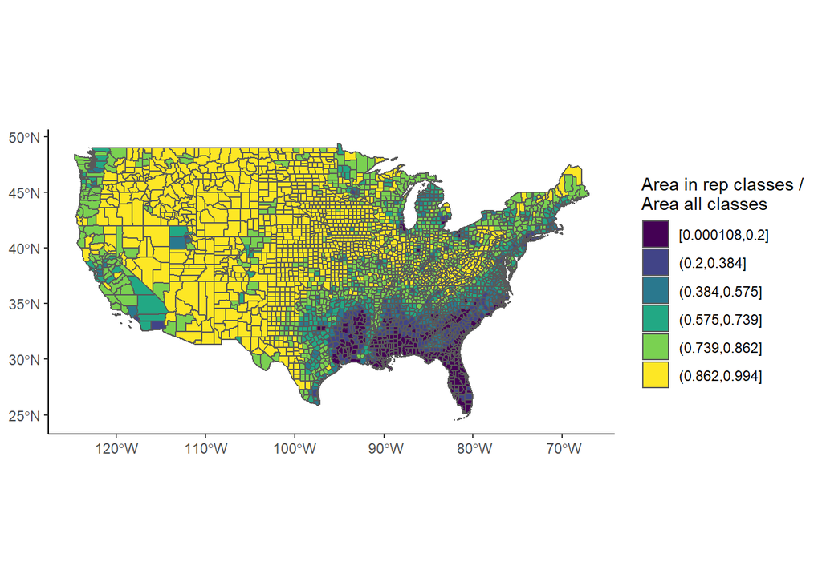

```r
natural.interval = BAMMtools::getJenksBreaks(toplot_sf$Rep_PctCounty, k = 7)
toplot_sf$population.natural = cut(toplot_sf$Rep_PctCounty, breaks=natural.interval, include.lowest = TRUE)

rep_map_jenks <- ggplot() + geom_sf(data=toplot_sf, aes(fill=population.natural)) +
  guides(fill=guide_legend(title='Area in rep classes /\nArea all classes')) +
  theme_classic() +
  scale_fill_viridis(discrete=T)
rep_map_jenks
```

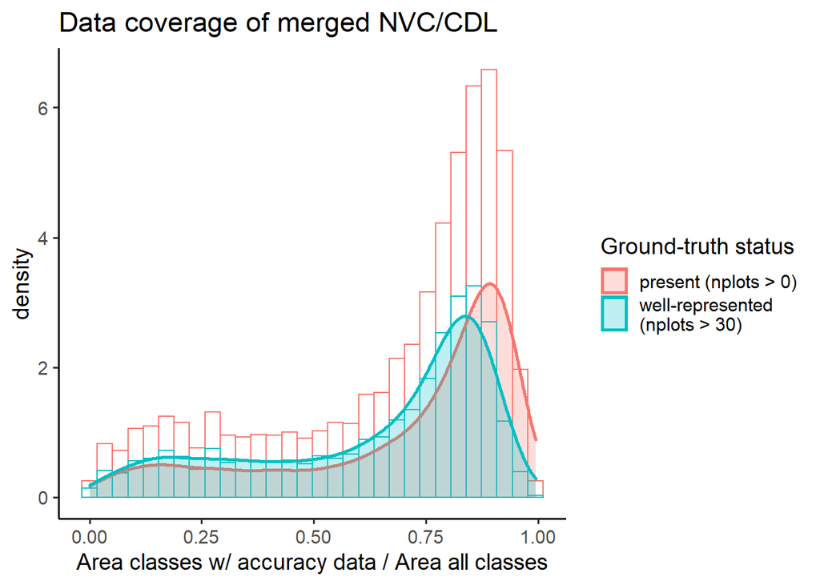

```r
# histogram of data coverage
tidyr::pivot_longer(toplot_sf, cols=c(Rep_PctCounty, WellRep_PctCounty), names_to='Type', values_to='DataCoverage') %>%
  ggplot(aes(x = DataCoverage)) +
  geom_histogram(aes(y=..density.., col=Type) ,
                 fill = "white") +
  geom_density(lwd = 1, aes(colour = Type, fill = Type), alpha = 0.25) +
  theme_classic(base_size=14) +
  ggtitle("Data coverage of merged NVC/CDL") +
  xlab("Area classes w/ accuracy data / Area all classes") +
  scale_fill_discrete(name = "Ground-truth status", labels=c('present (nplots > 0)', 'well-represented\n(nplots > 30)')) +
  scale_color_discrete(name = "Ground-truth status", labels=c('present (nplots > 0)', 'well-represented\n(nplots > 30)'))
```

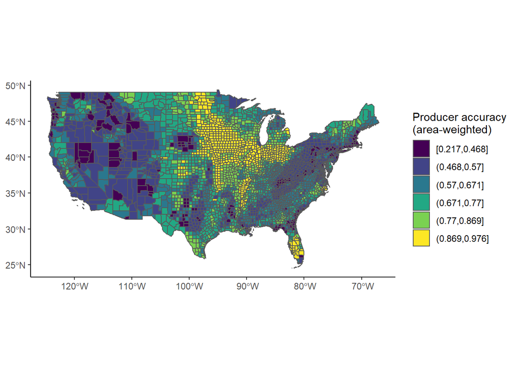

```r
# calculate jenk's breaks to use on map
natural.interval.pa <- BAMMtools::getJenksBreaks(toplot_sf$WtdProdAcc, k = 7)
toplot_sf$prodacc.natural = cut(toplot_sf$WtdProdAcc, breaks=natural.interval.pa, include.lowest = TRUE)

# map producer accuracy of NVC by county
prodacc_map_jenks <- ggplot() + geom_sf(data=toplot_sf, aes(fill=prodacc.natural)) +
  guides(fill=guide_legend(title='Producer accuracy \n(area-weighted)')) +
  theme_classic() +
  scale_fill_viridis(discrete=T)
prodacc_map_jenks
```

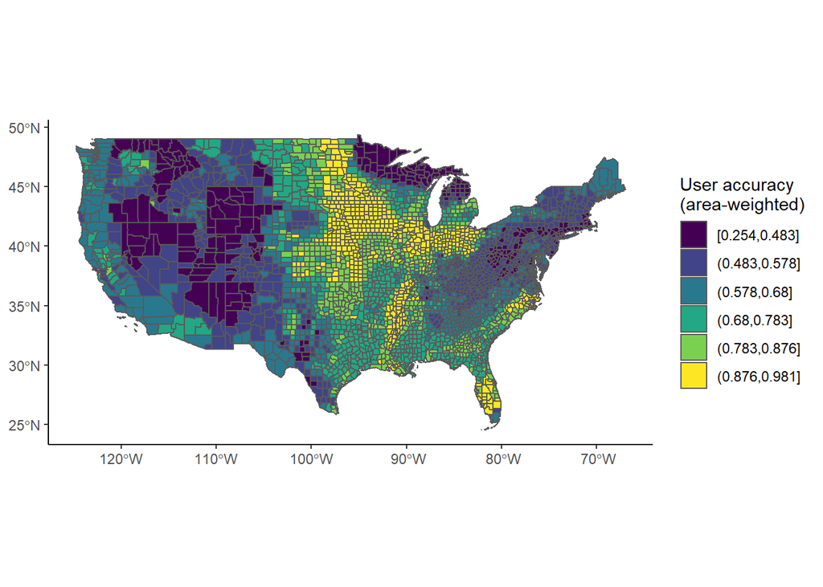

```r
natural.interval.ua = BAMMtools::getJenksBreaks(toplot_sf$WtdUserAcc, k = 7)
toplot_sf$useracc.natural = cut(toplot_sf$WtdUserAcc, breaks=natural.interval.ua, include.lowest = TRUE)

# map user accuracy of NVC by county
useracc_map_jenks  <- ggplot() + geom_sf(data=toplot_sf, aes(fill=useracc.natural)) +
  guides(fill=guide_legend(title='User accuracy \n(area-weighted)')) +
  theme_classic() +
  scale_fill_viridis(discrete=T)
useracc_map_jenks
```

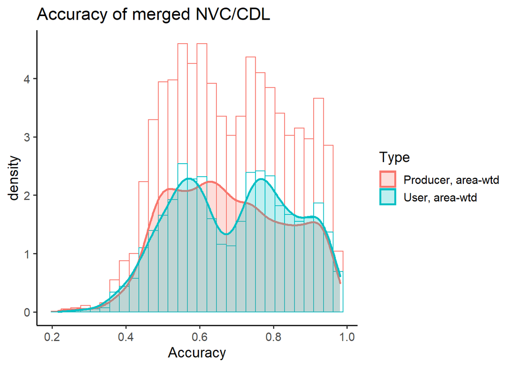

```r
# histogram of accuracy by county (user and producer)
tidyr::pivot_longer(toplot_sf, cols=c(WtdProdAcc, WtdUserAcc), names_to='Type', values_to='Accuracy') %>%
  ggplot(aes(x = Accuracy)) +
  geom_histogram(aes(y=..density.., col=Type) ,
                 fill = "white") +
  geom_density(lwd = 1, aes(colour = Type, fill = Type), alpha = 0.25) +
  theme_classic(base_size=14) +
  ggtitle("Accuracy of merged NVC/CDL")  +
  scale_fill_discrete(labels=c('Producer, area-wtd', 'User, area-wtd')) +
  scale_color_discrete(labels=c('Producer, area-wtd', 'User, area-wtd'))
```